# For Portfolio Weed Sales

```python
# Our usual libraries for working with data
import pandas as pd
import numpy as np

pd.options.display.max_columns = 100
# pd.options.display.max_rows = 100

# Our usual libraries for visualizing data
%matplotlib inline
import matplotlib.pyplot as plt
import matplotlib.colors as colors
import seaborn as sb

# Spatial libaries
import geopandas as gpd
import geoplot, contextily
```

## Read in data

### Sales data

Read in the "colorado_monthly_cannabis_sales.csv" file as `sales_df`.

```python
sales_df = pd.read_csv('colorado_monthly_cannabis_sales.csv')
sales_df.head()
```

|  | Time | County | Sales | Type |
| --- | --- | --- | --- | --- |
| 0 | 2014-01 | Adams | 683098.0 | Medical |
| 1 | 2014-01 | Pueblo | 419894.0 | Medical |
| 2 | 2014-01 | Routt | 239509.0 | Medical |
| 3 | 2014-01 | San Miguel | 164384.0 | Medical |
| 4 | 2014-01 | Sedgwick | NaN | Medical |

Print out the number of rows and show the tail of `sales_df`.

```python
print(sales_df.shape)
sales_df.tail()
```

```
(5398, 4)
```

|  | Time | County | Sales | Type |
| --- | --- | --- | --- | --- |
| 5393 | 2020-08 | Huerfano | 506634.0 | Recreational |
| 5394 | 2020-08 | Jefferson | 5805803.0 | Recreational |
| 5395 | 2020-08 | Lake | 449116.0 | Recreational |
| 5396 | 2020-08 | Garfield | 2538125.0 | Recreational |
| 5397 | 2020-08 | Bent | NaN | Recreational |

### Crime data

Read in the "co_county_crime.csv" file as `crime_df`.

```python
crime_df = pd.read_csv('co_county_crime.csv')
crime_df.head()
```

|  | Time | County | Type | Arrests |
| --- | --- | --- | --- | --- |
| 0 | 2013-01 | Adams | DUI | 301.0 |
| 1 | 2013-01 | Adams | Narcotics | 232.0 |
| 2 | 2013-01 | Alamosa | DUI | 0.0 |
| 3 | 2013-01 | Alamosa | Narcotics | 1.0 |
| 4 | 2013-01 | Arapahoe | DUI | 84.0 |

Print out the number of rows and show the tail of `crime_df`.

```python
print(crime_df.shape)
crime_df.tail()
```

```
(10668, 4)
```

|  | Time | County | Type | Arrests |
| --- | --- | --- | --- | --- |
| 10663 | 2019-12 | Washington | Narcotics | 0.0 |
| 10664 | 2019-12 | Weld | DUI | 65.0 |
| 10665 | 2019-12 | Weld | Narcotics | 71.0 |
| 10666 | 2019-12 | Yuma | DUI | 0.0 |
| 10667 | 2019-12 | Yuma | Narcotics | 0.0 |

### County shapefile

Read in the "co_counties" shapefiles as `co_counties_gdf`.

```python
co_counties_gdf = gpd.read_file('co_counties/co_counties/co_counties.shp')
```

Show the CRS.

```python
co_counties_gdf.crs
```

```
<Geographic 2D CRS: EPSG:4326>
Name: WGS 84
Axis Info [ellipsoidal]:
- Lat[north]: Geodetic latitude (degree)
- Lon[east]: Geodetic longitude (degree)
Area of Use:
- name: World
- bounds: (-180.0, -90.0, 180.0, 90.0)
Datum: World Geodetic System 1984
- Ellipsoid: WGS 84
- Prime Meridian: Greenwich
```

Print out the number of rows and show the tail of `co_counties_gdf`.

```python
print(co_counties_gdf.shape)
co_counties_gdf.head()
```

```
(64, 9)
```

|  | co_fips | county | househo_20 | pop_2010 | shape_st_1 | shape_st_2 | shape_star | shape_stle | geometry |
| --- | --- | --- | --- | --- | --- | --- | --- | --- | --- |
| 0 | 1.0 | ADAMS | 154502.0 | 441603.0 | 3.064413e+09 | 392729.110497 | 0.0 | 0.0 | POLYGON ((-103.70574 39.99991, -103.70569 39.9... |
| 1 | 3.0 | ALAMOSA | 6008.0 | 15445.0 | 1.872295e+09 | 177555.351470 | 0.0 | 0.0 | POLYGON ((-105.59917 37.75216, -105.51619 37.7... |
| 2 | 5.0 | ARAPAHOE | 225124.0 | 572003.0 | 2.084863e+09 | 335003.471310 | 0.0 | 0.0 | MULTIPOLYGON (((-103.70653 39.73986, -103.7066... |
| 3 | 7.0 | ARCHULETA | 5257.0 | 12084.0 | 3.504795e+09 | 263558.683443 | 0.0 | 0.0 | POLYGON ((-107.12854 37.42287, -107.12881 37.3... |
| 4 | 11.0 | BENT | 1835.0 | 6499.0 | 3.990976e+09 | 254662.200852 | 0.0 | 0.0 | POLYGON ((-102.74208 38.26675, -102.74211 38.2... |

## Feature engineering

### Sales data

In `sales_df`, cast the values in the "Month" column from strings to `pd.Timestamp` or `pd.Period` objects using an appropriate pandas function.

```python
sales_df['Time'] = pd.to_datetime(sales_df['Time'])
sales_df
```

|  | Time | County | Sales | Type |
| --- | --- | --- | --- | --- |
| 0 | 2014-01-01 | Adams | 683098.0 | Medical |
| 1 | 2014-01-01 | Pueblo | 419894.0 | Medical |
| 2 | 2014-01-01 | Routt | 239509.0 | Medical |
| 3 | 2014-01-01 | San Miguel | 164384.0 | Medical |
| 4 | 2014-01-01 | Sedgwick | NaN | Medical |
| ... | ... | ... | ... | ... |
| 5393 | 2020-08-01 | Huerfano | 506634.0 | Recreational |
| 5394 | 2020-08-01 | Jefferson | 5805803.0 | Recreational |
| 5395 | 2020-08-01 | Lake | 449116.0 | Recreational |
| 5396 | 2020-08-01 | Garfield | 2538125.0 | Recreational |
| 5397 | 2020-08-01 | Bent | NaN | Recreational |

5398 rows × 4 columns

> "Per §39-21-113(4), C.R.S., data derived from taxpayer returns is aggregated in order to protect the confidentiality of individual taxpayers. It is the Department’s practice to release aggregated data only when there are at least three taxpayers in a given category and none of them represents more than 80% of the total.

This is a good case for keeping rather than dropping NaNs: because a county doesn't report sales doesn't mean that it's not a legal county with dispensaries and sales.

### Crime data

In `crime_df`, cast the values in the "Month" column from strings to `pd.Timestamp` or `pd.Period` objects using an appropriate pandas function.

```python
crime_df['Time'] = pd.to_datetime(crime_df['Time'])
crime_df
```

|  | Time | County | Type | Arrests |
| --- | --- | --- | --- | --- |
| 0 | 2013-01-01 | Adams | DUI | 301.0 |
| 1 | 2013-01-01 | Adams | Narcotics | 232.0 |
| 2 | 2013-01-01 | Alamosa | DUI | 0.0 |
| 3 | 2013-01-01 | Alamosa | Narcotics | 1.0 |
| 4 | 2013-01-01 | Arapahoe | DUI | 84.0 |
| ... | ... | ... | ... | ... |
| 10663 | 2019-12-01 | Washington | Narcotics | 0.0 |
| 10664 | 2019-12-01 | Weld | DUI | 65.0 |
| 10665 | 2019-12-01 | Weld | Narcotics | 71.0 |
| 10666 | 2019-12-01 | Yuma | DUI | 0.0 |
| 10667 | 2019-12-01 | Yuma | Narcotics | 0.0 |

10668 rows × 4 columns

### Counties data

Convert the "county" column in `co_counties_gdf` to title-case ([hint](https://pandas.pydata.org/pandas-docs/stable/reference/api/pandas.Series.str.title.html)) and show the head after the change.

```python
co_counties_gdf['county'] = co_counties_gdf['county'].str.title()
co_counties_gdf.head()
```

|  | co_fips | county | househo_20 | pop_2010 | shape_st_1 | shape_st_2 | shape_star | shape_stle | geometry |
| --- | --- | --- | --- | --- | --- | --- | --- | --- | --- |
| 0 | 1.0 | Adams | 154502.0 | 441603.0 | 3.064413e+09 | 392729.110497 | 0.0 | 0.0 | POLYGON ((-103.70574 39.99991, -103.70569 39.9... |
| 1 | 3.0 | Alamosa | 6008.0 | 15445.0 | 1.872295e+09 | 177555.351470 | 0.0 | 0.0 | POLYGON ((-105.59917 37.75216, -105.51619 37.7... |
| 2 | 5.0 | Arapahoe | 225124.0 | 572003.0 | 2.084863e+09 | 335003.471310 | 0.0 | 0.0 | MULTIPOLYGON (((-103.70653 39.73986, -103.7066... |
| 3 | 7.0 | Archuleta | 5257.0 | 12084.0 | 3.504795e+09 | 263558.683443 | 0.0 | 0.0 | POLYGON ((-107.12854 37.42287, -107.12881 37.3... |
| 4 | 11.0 | Bent | 1835.0 | 6499.0 | 3.990976e+09 | 254662.200852 | 0.0 | 0.0 | POLYGON ((-102.74208 38.26675, -102.74211 38.2... |

## Exploratory analysis

### Sales data

How many times does each county appear in `sales_df`?

```python
g=sales_df.groupby('County')

county_count = g.size().to_frame().reset_index()

county_count = county_count.rename(columns={0: "Appeared"})

county_count.sort_values(by=['Appeared'], ascending=False)
```

|  | County | Appeared |
| --- | --- | --- |
| 0 | Adams | 160 |
| 12 | Denver | 160 |
| 41 | Summit | 160 |
| 39 | San Miguel | 160 |
| 36 | Routt | 160 |
| 35 | Pueblo | 160 |
| 33 | Park | 160 |
| 21 | Jefferson | 160 |
| 16 | Garfield | 160 |
| 43 | Weld | 160 |
| 5 | Boulder | 159 |
| 34 | Pitkin | 158 |
| 24 | Larimer | 157 |
| 13 | Eagle | 156 |
| 7 | Clear Creek | 155 |
| 14 | El Paso | 154 |
| 40 | Sedgwick | 153 |
| 6 | Chaffee | 153 |
| 22 | La Plata | 152 |
| 2 | Arapahoe | 151 |
| 18 | Grand | 150 |
| 28 | Montezuma | 149 |
| 26 | Mesa | 148 |
| 30 | Morgan | 144 |
| 25 | Las Animas | 139 |
| 17 | Gilpin | 136 |
| 32 | Ouray | 135 |
| 19 | Gunnison | 129 |
| 3 | Archuleta | 129 |
| 9 | Costilla | 116 |
| 27 | Moffat | 109 |
| 29 | Montrose | 95 |
| 37 | Saguache | 84 |
| 23 | Lake | 80 |
| 1 | Alamosa | 80 |
| 15 | Fremont | 80 |
| 31 | Otero | 70 |
| 38 | San Juan | 68 |
| 20 | Huerfano | 63 |
| 8 | Conejos | 62 |
| 42 | Teller | 45 |
| 10 | Crowley | 16 |
| 11 | Delta | 12 |
| 4 | Bent | 11 |

Make a histogram of the "Sales" values in `sales_df`. This might be highly-skewed, so experiment with using log-scaled bins and x-axis: try passing `np.logspace(3,8,25)` to the "bins" parameter and set the xscale to "log" ([hint](https://matplotlib.org/3.2.1/api/_as_gen/matplotlib.axes.Axes.set_xscale.html)). Make sure to label your axes. Real extra credit if you can format the x-axis to have more interpretable ticks too ([hint](https://matplotlib.org/3.3.1/gallery/ticks_and_spines/tick-formatters.html)).

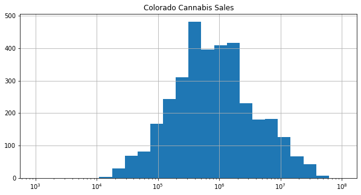

```python
f,ax = plt.subplots(figsize=(10,5))
ax.set_xscale('log')
ax.set_title('Colorado Cannabis Sales')
sales_df['Sales'].hist(ax=ax,bins=np.logspace(3,8,25))
```

Interpret the histogram. What is the most common monthly sales value?

Reshape the data with "Time" in the index and "Medical" and "Recreational" as columns and the total number of sales as values. Save the resulting reshape as `monthly_sales_pivot`. You can do this with a pivot table or a groupby-aggregation. Show the tail of this reshaped DataFrame.

```python
monthly_sales_pivot = pd.pivot_table(sales_df,
                             index='Time',
                             columns='Type',
                             values='Sales',
                             aggfunc='sum'
                            )

monthly_sales_pivot.head()
```

| Type Time | Medical | Recreational |
| --- | --- | --- |
| 2014-01-01 | 32105349.0 | 11606429.0 |
| 2014-02-01 | 31203950.0 | 11905758.0 |
| 2014-03-01 | 33964665.0 | 16799118.0 |
| 2014-04-01 | 32079528.0 | 18520452.0 |
| 2014-05-01 | 30832970.0 | 18920521.0 |

Make a lineplot of total medical and recreational cannabis sales by month using the DataFrame above. Label your axes and title. Real extra credit if you can format the y-axis to have more interpretable ticks too ([hint](https://matplotlib.org/3.1.0/gallery/ticks_and_spines/custom_ticker1.html)).

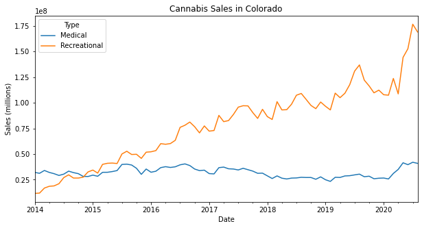

```python
f,ax=plt.subplots(figsize=(10,5))

monthly_sales_pivot.plot(ax=ax,
                        ylabel='Sales (millions)',
                         xlabel='Date',
                        title='Cannabis Sales in Colorado')
```

Pick a county in Colorado and filter original sales DataFrame to only that county's values. Note that not all counties permit medical and/or recreational sales and thus may not be present in the data or they have changed their policies over time creating gaps. Make sure to pick a county with recreational sales. Reshape the data to include recreational and medical like we did above. Save the result as `county_monthly_sales_pivot`. Show the tail of this data.

```python
denver_sales_df = sales_df[sales_df['County'] == 'Denver']

denver_sales_df
```

|  | Time | County | Sales | Type |
| --- | --- | --- | --- | --- |
| 10 | 2014-01-01 | Denver | 8482593.0 | Recreational |
| 33 | 2014-01-01 | Denver | 15351083.0 | Medical |
| 57 | 2014-02-01 | Denver | 8349069.0 | Recreational |
| 75 | 2014-02-01 | Denver | 14680476.0 | Medical |
| 97 | 2014-03-01 | Denver | 16102218.0 | Medical |
| ... | ... | ... | ... | ... |
| 5256 | 2020-06-01 | Denver | 47719774.0 | Recreational |
| 5286 | 2020-07-01 | Denver | 20149552.0 | Medical |
| 5311 | 2020-07-01 | Denver | 55559414.0 | Recreational |
| 5353 | 2020-08-01 | Denver | 19551025.0 | Medical |
| 5386 | 2020-08-01 | Denver | 52011403.0 | Recreational |

160 rows × 4 columns

```python
denver_monthly_sales_pivot = pd.pivot_table(data=denver_sales_df,
                                            index='Time',
                                            columns='Type',
                                            values='Sales',
                                            aggfunc='sum'
                                           )

denver_monthly_sales_pivot.head()
```

| Type Time | Medical | Recreational |
| --- | --- | --- |
| 2014-01-01 | 15351083.0 | 8482593.0 |
| 2014-02-01 | 14680476.0 | 8349069.0 |
| 2014-03-01 | 16102218.0 | 10746117.0 |
| 2014-04-01 | 15064678.0 | 12005332.0 |
| 2014-05-01 | 14150620.0 | 11300905.0 |

Visualize the county-level data over time as a line plot like we did above.

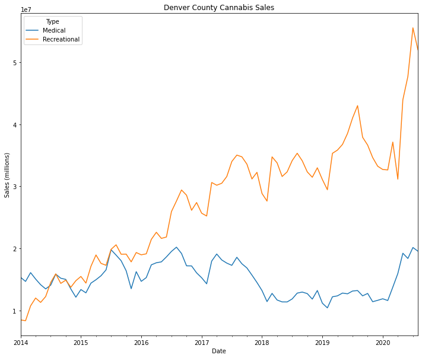

```python
f,ax=plt.subplots(figsize=(12,10))
denver_monthly_sales_pivot.plot(ax=ax,
                               ylabel='Sales (millions)',
                               xlabel='Date',
                               title="Denver County Cannabis Sales")
```

### Crime data

How many times does each county appear in `crime_df`?

```python
g=crime_df.groupby('County')

crime_county_count = g.size().to_frame().reset_index()

crime_county_count = crime_county_count.rename(columns={0: "Appeared"})

crime_county_count.sort_values(by=['Appeared'], ascending=False)
```

|  | County | Appeared |
| --- | --- | --- |
| 0 | Adams | 168 |
| 1 | Alamosa | 168 |
| 34 | La Plata | 168 |
| 35 | Lake | 168 |
| 36 | Larimer | 168 |
| ... | ... | ... |
| 29 | Huerfano | 168 |
| 64 | Yuma | 168 |
| 30 | Jackson | 84 |
| 11 | Colorado Bureau of Investigation | 84 |
| 41 | Mineral | 84 |

65 rows × 2 columns

Reshape the data with "Time" in the index and "DUI" and "Narcotics" as columns and the total number of arrests as values. You can do this with a pivot table or a groupby-aggregation. Save the result as `monthly_crime_pivot` and show the tail.

```python
monthly_crime_pivot = pd.pivot_table(data=crime_df,
                                    index='Time',
                                    columns='Type',
                                    values='Arrests',
                                    aggfunc='sum'
                                           )

monthly_crime_pivot.head()
```

| Type Time | DUI | Narcotics |
| --- | --- | --- |
| 2013-01-01 | 1725.0 | 1077.0 |
| 2013-02-01 | 1871.0 | 1120.0 |
| 2013-03-01 | 2299.0 | 1046.0 |
| 2013-04-01 | 1860.0 | 999.0 |
| 2013-05-01 | 2240.0 | 1030.0 |

Make a lineplot of total DUI and Narcotics arrests by month using `monthly_crime_pivot`. Label your axes and title.

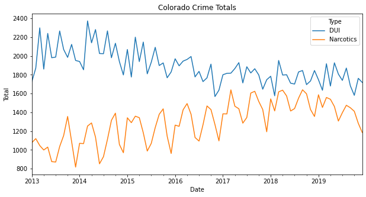

```python
f,ax=plt.subplots(figsize=(10,5))
monthly_crime_pivot.plot(ax=ax,
                         ylabel='Total',
                         xlabel='Date',
                         title="Colorado Crime Totals")
```

Pick a county in Colorado and filter the crime DataFrame to only that county's values. Reshape the data to include DUIs and Narcotics like we did above. Save as `county_monthly_crime_pivot`. Show the tail of this data.

```python
denver_crimes_df = crime_df[crime_df['County'] == 'Denver']

denver_crimes_df.head()
```

|  | Time | County | Type | Arrests |
| --- | --- | --- | --- | --- |
| 33 | 2013-01-01 | Denver | DUI | 7.0 |
| 34 | 2013-01-01 | Denver | Narcotics | 188.0 |
| 160 | 2013-02-01 | Denver | DUI | 10.0 |
| 161 | 2013-02-01 | Denver | Narcotics | 196.0 |
| 287 | 2013-03-01 | Denver | DUI | 169.0 |

```python
county_monthly_crime_pivot = pd.pivot_table(data=denver_crimes_df,
                                            index='Time',
                                            columns='Type',
                                            values='Arrests',
                                            aggfunc='sum'
                                           )

county_monthly_crime_pivot.head()
```

| Type Time | DUI | Narcotics |
| --- | --- | --- |
| 2013-01-01 | 7.0 | 188.0 |
| 2013-02-01 | 10.0 | 196.0 |
| 2013-03-01 | 169.0 | 146.0 |
| 2013-04-01 | 163.0 | 159.0 |
| 2013-05-01 | 197.0 | 186.0 |

Visualize the county-level data over time as a line plot like we did above.

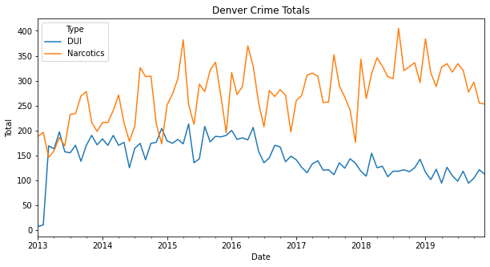

```python
county_monthly_crime_pivot.plot(figsize=(10,5),
                                ylabel='Total',
                                xlabel='Date',
                                title="Denver Crime Totals")
```

### Combine both state-level datasets

Use `pd.merge` to combine the reshaped state-level DataFrames using an "inner" join called `combined_df` and inspect.

combined_df

```python
combined_df = pd.merge(left = monthly_sales_pivot,
                       right = monthly_crime_pivot,
                       how = 'inner',
                       left_on = 'Time',
                       right_on = 'Time'
                      )
combined_df.rename(columns={'Type_x':'Weed Type','Type_y':'Arrest Type'},inplace=True)
combined_df.head()
```

| Type Time | Medical | Recreational | DUI | Narcotics |
| --- | --- | --- | --- | --- |
| 2014-01-01 | 32105349.0 | 11606429.0 | 1941.0 | 1070.0 |
| 2014-02-01 | 31203950.0 | 11905758.0 | 1853.0 | 1067.0 |
| 2014-03-01 | 33964665.0 | 16799118.0 | 2373.0 | 1254.0 |
| 2014-04-01 | 32079528.0 | 18520452.0 | 2140.0 | 1287.0 |
| 2014-05-01 | 30832970.0 | 18920521.0 | 2281.0 | 1136.0 |

#### Create a new normalized DataFrame called `normalized_df` by [dividing](https://pandas.pydata.org/pandas-docs/stable/reference/api/pandas.DataFrame.divide.html) by the January 2014 values in each column.

```python
normalized_df = combined_df.divide(combined_df.loc['2014-01-01'])
```

Inspect the head of `normalized_df` to confirm the January 1, 2014 values are 1.

```python
normalized_df.head()
```

| Type Time | Medical | Recreational | DUI | Narcotics |
| --- | --- | --- | --- | --- |
| 2014-01-01 | 1.000000 | 1.000000 | 1.000000 | 1.000000 |
| 2014-02-01 | 0.971924 | 1.025790 | 0.954663 | 0.997196 |
| 2014-03-01 | 1.057913 | 1.447398 | 1.222566 | 1.171963 |
| 2014-04-01 | 0.999196 | 1.595706 | 1.102524 | 1.202804 |
| 2014-05-01 | 0.960369 | 1.630176 | 1.175167 | 1.061682 |

Using `normalized_df`, make a line plot with the normalized DUI and Recreational values.

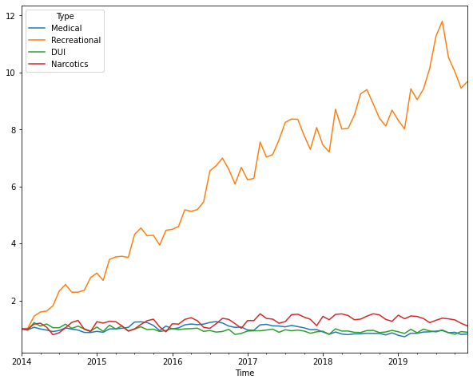

```python
normalized_df.plot(figsize=(10,8))
```

Is this a helpful visualization? Why or why not?

This plot is helpful to see how recreational marijuana has taken off since it was first legalized. When can see from this plot that it has grown substantially in the last few years. Other than that, this graph is not helpful.

Compute the [correlation coefficients](https://pandas.pydata.org/pandas-docs/stable/reference/api/pandas.DataFrame.corr.html) between the columns in `normalized_df`. (The values are symmetrical around the diagonal.) Pick two different values and interpret them.

```python
normalized_df.corr()
```

| Type | Medical | Recreational | DUI | Narcotics |
| --- | --- | --- | --- | --- |
| Medical | 1.000000 | -0.313120 | 0.276697 | -0.208629 |
| Recreational | -0.313120 | 1.000000 | -0.628621 | 0.629456 |
| DUI | 0.276697 | -0.628621 | 1.000000 | -0.240662 |
| Narcotics | -0.208629 | 0.629456 | -0.240662 | 1.000000 |

The highest correlation I see in this data frame between 2 different data points is between Narcotics and Recreational marijuana. This makes sense for the fact that it has become legalized means there will be more people illegally carrying weed in public. Also, this would have lead drug dealers to move on from selling weed to another drug which could have also lead to an increase in narcotics for recreational marijuana

Using `normalized_df`, make a scatter plot with "Recreational" on the x-axis and "DUI" on the y-axis.

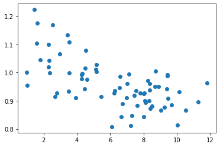

```python
plt.scatter(data=normalized_df,
           x='Recreational',
           y="DUI")
```

Interpret the plot.

Using `normalized_df`, make a scatter plot data with "Recreational" on the x-axis and "Narcotics" on the y-axis.

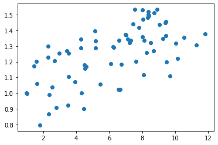

```python
plt.scatter(data=normalized_df,
           x='Recreational',
           y="Narcotics")
```

Interpet this plot.

This plot shows that there is a bit of a correlation between recreational marijuana and narcotic arrests. I see this by noticing there is more of y as you travel right on the x-axis.

## Spatial visualization

### Sales data

Merge the county GeoDataFrame (left) with the original sales data (right) with a left join on the county names to a GeoDataFrame called `sales_gdf`. Check to make sure the merged object is a GeoDataFrame, print the shape, and inspect the head.

```python
sales_gdf = pd.merge(left=co_counties_gdf,
                    right=sales_df,
                    how='left',
                    left_on='county',
                    right_on='County')

print(sales_gdf.shape)
sales_gdf.head()
```

```
(5418, 13)
```

|  | co_fips | county | househo_20 | pop_2010 | shape_st_1 | shape_st_2 | shape_star | shape_stle | geometry | Time | County | Sales | Type |
| --- | --- | --- | --- | --- | --- | --- | --- | --- | --- | --- | --- | --- | --- |
| 0 | 1.0 | Adams | 154502.0 | 441603.0 | 3.064413e+09 | 392729.110497 | 0.0 | 0.0 | POLYGON ((-103.70574 39.99991, -103.70569 39.9... | 2014-01-01 | Adams | 683098.0 | Medical |
| 1 | 1.0 | Adams | 154502.0 | 441603.0 | 3.064413e+09 | 392729.110497 | 0.0 | 0.0 | POLYGON ((-103.70574 39.99991, -103.70569 39.9... | 2014-01-01 | Adams | NaN | Recreational |
| 2 | 1.0 | Adams | 154502.0 | 441603.0 | 3.064413e+09 | 392729.110497 | 0.0 | 0.0 | POLYGON ((-103.70574 39.99991, -103.70569 39.9... | 2014-02-01 | Adams | NaN | Recreational |
| 3 | 1.0 | Adams | 154502.0 | 441603.0 | 3.064413e+09 | 392729.110497 | 0.0 | 0.0 | POLYGON ((-103.70574 39.99991, -103.70569 39.9... | 2014-02-01 | Adams | 454940.0 | Medical |
| 4 | 1.0 | Adams | 154502.0 | 441603.0 | 3.064413e+09 | 392729.110497 | 0.0 | 0.0 | POLYGON ((-103.70574 39.99991, -103.70569 39.9... | 2014-03-01 | Adams | NaN | Recreational |

Filter the data to "Recreational" sales in December 2014. Visualize the "Sales" as a choropleth. Bonus points for using a basemap. Extra bonus points for using a [lognorm colormap](https://matplotlib.org/3.1.0/gallery/userdemo/colormap_normalizations_lognorm.html).

```python
december_sales_gdf = sales_gdf[sales_gdf['Time'] == '2014-12-01']
december_sales_gdf = december_sales_gdf[december_sales_gdf['Type'] == 'Recreational']
december_sales_gdf.head()
```

|  | co_fips | county | househo_20 | pop_2010 | shape_st_1 | shape_st_2 | shape_star | shape_stle | geometry | Time | County | Sales | Type |
| --- | --- | --- | --- | --- | --- | --- | --- | --- | --- | --- | --- | --- | --- |
| 22 | 1.0 | Adams | 154502.0 | 441603.0 | 3.064413e+09 | 392729.110497 | 0.0 | 0.0 | POLYGON ((-103.70574 39.99991, -103.70569 39.9... | 2014-12-01 | Adams | 1445817.0 | Recreational |
| 253 | 5.0 | Arapahoe | 225124.0 | 572003.0 | 2.084863e+09 | 335003.471310 | 0.0 | 0.0 | MULTIPOLYGON (((-103.70653 39.73986, -103.7066... | 2014-12-01 | Arapahoe | 1416559.0 | Recreational |
| 405 | 7.0 | Archuleta | 5257.0 | 12084.0 | 3.504795e+09 | 263558.683443 | 0.0 | 0.0 | POLYGON ((-107.12854 37.42287, -107.12881 37.3... | 2014-12-01 | Archuleta | NaN | Recreational |
| 552 | 13.0 | Boulder | 119574.0 | 294567.0 | 1.917501e+09 | 221747.555049 | 0.0 | 0.0 | MULTIPOLYGON (((-105.25048 40.26275, -105.2425... | 2014-12-01 | Boulder | 3592405.0 | Recreational |
| 706 | 15.0 | Chaffee | 7596.0 | 17809.0 | 2.625616e+09 | 299305.408749 | 0.0 | 0.0 | POLYGON ((-106.44112 39.05674, -106.38695 39.0... | 2014-12-01 | Chaffee | NaN | Recreational |

[figure not shown]

```python
december_sales_3857_gdf = december_sales_gdf.to_crs('EPSG:3857')
f,ax = plt.subplots(figsize=(10,8))

december_sales_3857_gdf.plot(column = 'Sales',
                             cmap = 'jet',
                             legend = True,
                             edgecolor = 'k',
                             alpha = .5,
                             legend_kwds={'shrink':.5},
                             ax=ax)

contextily.add_basemap(ax,source=contextily.providers.OpenStreetMap.Mapnik)
```

Filter the data to "Recreational" sales in December 2019. Visualize the "Sales" as a choropleth. Bonus points for using a basemap. Extra bonus points for using a [lognorm colormap](https://matplotlib.org/3.1.0/gallery/userdemo/colormap_normalizations_lognorm.html).

```python
december19_sales_gdf = sales_gdf[sales_gdf['Time'] == '2019-12-01']
december19_sales_gdf = december19_sales_gdf[december19_sales_gdf['Type'] == 'Recreational']
december19_sales_gdf.head()
```

|  | co_fips | county | househo_20 | pop_2010 | shape_st_1 | shape_st_2 | shape_star | shape_stle | geometry | Time | County | Sales | Type |
| --- | --- | --- | --- | --- | --- | --- | --- | --- | --- | --- | --- | --- | --- |
| 142 | 1.0 | Adams | 154502.0 | 441603.0 | 3.064413e+09 | 392729.110497 | 0.0 | 0.0 | POLYGON ((-103.70574 39.99991, -103.70569 39.9... | 2019-12-01 | Adams | 9632162.0 | Recreational |
| 373 | 5.0 | Arapahoe | 225124.0 | 572003.0 | 2.084863e+09 | 335003.471310 | 0.0 | 0.0 | MULTIPOLYGON (((-103.70653 39.73986, -103.7066... | 2019-12-01 | Arapahoe | 12359535.0 | Recreational |
| 511 | 7.0 | Archuleta | 5257.0 | 12084.0 | 3.504795e+09 | 263558.683443 | 0.0 | 0.0 | POLYGON ((-107.12854 37.42287, -107.12881 37.3... | 2019-12-01 | Archuleta | 893754.0 | Recreational |
| 522 | 11.0 | Bent | 1835.0 | 6499.0 | 3.990976e+09 | 254662.200852 | 0.0 | 0.0 | POLYGON ((-102.74208 38.26675, -102.74211 38.2... | 2019-12-01 | Bent | NaN | Recreational |
| 673 | 13.0 | Boulder | 119574.0 | 294567.0 | 1.917501e+09 | 221747.555049 | 0.0 | 0.0 | MULTIPOLYGON (((-105.25048 40.26275, -105.2425... | 2019-12-01 | Boulder | 8622927.0 | Recreational |

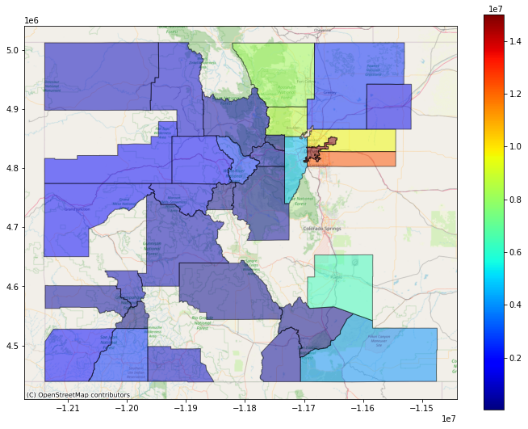

```python
december19_sales_3857_gdf = december19_sales_gdf.to_crs('EPSG:3857')

f,ax = plt.subplots(figsize=(12,15))

december19_sales_3857_gdf.plot(column = 'Sales',
                               cmap = 'jet',
                               legend = True,
                               edgecolor = 'k',
                               alpha = .5,
                               vmax=15000000,
                               legend_kwds={'shrink':.6},
                               ax=ax)

contextily.add_basemap(ax,source=contextily.providers.OpenStreetMap.Mapnik)
```

Interpet some changes you observe between the two maps.

I changed the vmax to what the highest sales were in 2014 so that the 2019 map showed the true increase in sales for counties besides Denver. I know Denver is the most dominant when it comes to sales in recreational weed so I know it would still be the top.

Looking at other counties we can see how much they increased sales from recreational weed. For example, if you look at Boulder and Larimer county you can see that they went from a dark blue to a light green almost yellow. We can also see that are more counties on the map meaning there were enough stores added in these counties to be counted in the sales database.

### Crime data

Merge `co_counties_gdf` (left) with `crime_df` (right) into a GeoDataFrame called `crime_gdf`. Check to make sure the merged object is a GeoDataFrame, print the shape, and inspect the head.

```python
crime_gdf = pd.merge(left=co_counties_gdf,
                    right=crime_df,
                    how='left',
                    left_on='county',
                    right_on='County')

print(crime_gdf.shape)
crime_gdf.head()
```

```
(10417, 13)
```

|  | co_fips | county | househo_20 | pop_2010 | shape_st_1 | shape_st_2 | shape_star | shape_stle | geometry | Time | County | Type | Arrests |
| --- | --- | --- | --- | --- | --- | --- | --- | --- | --- | --- | --- | --- | --- |
| 0 | 1.0 | Adams | 154502.0 | 441603.0 | 3.064413e+09 | 392729.110497 | 0.0 | 0.0 | POLYGON ((-103.70574 39.99991, -103.70569 39.9... | 2013-01-01 | Adams | DUI | 301.0 |
| 1 | 1.0 | Adams | 154502.0 | 441603.0 | 3.064413e+09 | 392729.110497 | 0.0 | 0.0 | POLYGON ((-103.70574 39.99991, -103.70569 39.9... | 2013-01-01 | Adams | Narcotics | 232.0 |
| 2 | 1.0 | Adams | 154502.0 | 441603.0 | 3.064413e+09 | 392729.110497 | 0.0 | 0.0 | POLYGON ((-103.70574 39.99991, -103.70569 39.9... | 2013-02-01 | Adams | DUI | 369.0 |
| 3 | 1.0 | Adams | 154502.0 | 441603.0 | 3.064413e+09 | 392729.110497 | 0.0 | 0.0 | POLYGON ((-103.70574 39.99991, -103.70569 39.9... | 2013-02-01 | Adams | Narcotics | 221.0 |
| 4 | 1.0 | Adams | 154502.0 | 441603.0 | 3.064413e+09 | 392729.110497 | 0.0 | 0.0 | POLYGON ((-103.70574 39.99991, -103.70569 39.9... | 2013-03-01 | Adams | DUI | 446.0 |

Filter the data to "DUI" sales in December 2014. Visualize the "Arrests" as a choropleth. Bonus points for using a basemap. Extra bonus points for using a [lognorm](https://matplotlib.org/3.1.0/gallery/userdemo/colormap_normalizations_lognorm.html) or [symlognorm](https://matplotlib.org/3.3.1/gallery/userdemo/colormap_normalizations_symlognorm.html#sphx-glr-gallery-userdemo-colormap-normalizations-symlognorm-py).

```python
december_DUI_gdf = crime_gdf[crime_gdf['Time'] == '2014-12-01']
december_DUI_gdf = december_DUI_gdf[december_DUI_gdf['Type'] == 'DUI']
december_DUI_gdf.head()
```

|  | co_fips | county | househo_20 | pop_2010 | shape_st_1 | shape_st_2 | shape_star | shape_stle | geometry | Time | County | Type | Arrests |
| --- | --- | --- | --- | --- | --- | --- | --- | --- | --- | --- | --- | --- | --- |
| 46 | 1.0 | Adams | 154502.0 | 441603.0 | 3.064413e+09 | 392729.110497 | 0.0 | 0.0 | POLYGON ((-103.70574 39.99991, -103.70569 39.9... | 2014-12-01 | Adams | DUI | 332.0 |
| 214 | 3.0 | Alamosa | 6008.0 | 15445.0 | 1.872295e+09 | 177555.351470 | 0.0 | 0.0 | POLYGON ((-105.59917 37.75216, -105.51619 37.7... | 2014-12-01 | Alamosa | DUI | 0.0 |
| 382 | 5.0 | Arapahoe | 225124.0 | 572003.0 | 2.084863e+09 | 335003.471310 | 0.0 | 0.0 | MULTIPOLYGON (((-103.70653 39.73986, -103.7066... | 2014-12-01 | Arapahoe | DUI | 81.0 |
| 550 | 7.0 | Archuleta | 5257.0 | 12084.0 | 3.504795e+09 | 263558.683443 | 0.0 | 0.0 | POLYGON ((-107.12854 37.42287, -107.12881 37.3... | 2014-12-01 | Archuleta | DUI | 3.0 |
| 718 | 11.0 | Bent | 1835.0 | 6499.0 | 3.990976e+09 | 254662.200852 | 0.0 | 0.0 | POLYGON ((-102.74208 38.26675, -102.74211 38.2... | 2014-12-01 | Bent | DUI | 0.0 |

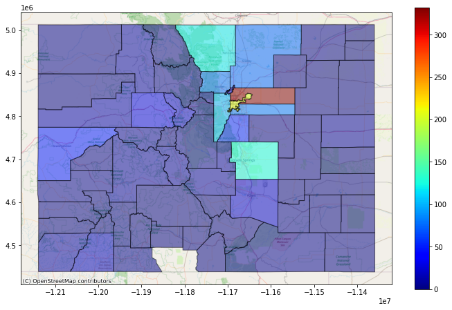

```python
december_DUI_3857_gdf = december_DUI_gdf.to_crs('EPSG:3857')

f,ax = plt.subplots(figsize=(12,15))

december_DUI_3857_gdf.plot(column = 'Arrests',
                           cmap = 'jet',
                           legend = True,
                           edgecolor = 'k',
                           alpha = .5,
                           legend_kwds={'shrink':.5},
                           ax=ax)

contextily.add_basemap(ax,source=contextily.providers.OpenStreetMap.Mapnik)
```

Filter the data to "DUI" sales in December 2019. Visualize the "Arrests" as a choropleth. Bonus points for using a basemap. Extra bonus points for using a [lognorm](https://matplotlib.org/3.1.0/gallery/userdemo/colormap_normalizations_lognorm.html) or [symlognorm](https://matplotlib.org/3.3.1/gallery/userdemo/colormap_normalizations_symlognorm.html#sphx-glr-gallery-userdemo-colormap-normalizations-symlognorm-py).

```python
december19_DUI_gdf = crime_gdf[crime_gdf['Time'] == '2019-12-01']
december19_DUI_gdf = december19_DUI_gdf[december19_DUI_gdf['Type'] == 'DUI']
december19_DUI_gdf.head()
```

|  | co_fips | county | househo_20 | pop_2010 | shape_st_1 | shape_st_2 | shape_star | shape_stle | geometry | Time | County | Type | Arrests |
| --- | --- | --- | --- | --- | --- | --- | --- | --- | --- | --- | --- | --- | --- |
| 166 | 1.0 | Adams | 154502.0 | 441603.0 | 3.064413e+09 | 392729.110497 | 0.0 | 0.0 | POLYGON ((-103.70574 39.99991, -103.70569 39.9... | 2019-12-01 | Adams | DUI | 210.0 |
| 334 | 3.0 | Alamosa | 6008.0 | 15445.0 | 1.872295e+09 | 177555.351470 | 0.0 | 0.0 | POLYGON ((-105.59917 37.75216, -105.51619 37.7... | 2019-12-01 | Alamosa | DUI | 2.0 |
| 502 | 5.0 | Arapahoe | 225124.0 | 572003.0 | 2.084863e+09 | 335003.471310 | 0.0 | 0.0 | MULTIPOLYGON (((-103.70653 39.73986, -103.7066... | 2019-12-01 | Arapahoe | DUI | 71.0 |
| 670 | 7.0 | Archuleta | 5257.0 | 12084.0 | 3.504795e+09 | 263558.683443 | 0.0 | 0.0 | POLYGON ((-107.12854 37.42287, -107.12881 37.3... | 2019-12-01 | Archuleta | DUI | 7.0 |
| 838 | 11.0 | Bent | 1835.0 | 6499.0 | 3.990976e+09 | 254662.200852 | 0.0 | 0.0 | POLYGON ((-102.74208 38.26675, -102.74211 38.2... | 2019-12-01 | Bent | DUI | 0.0 |

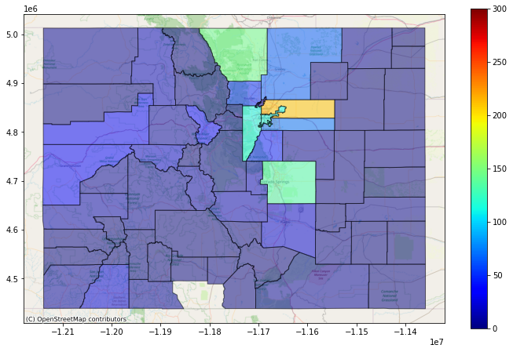

```python
december19_DUI_3857_gdf = december19_DUI_gdf.to_crs('EPSG:3857')

f,ax = plt.subplots(figsize=(12,15))

december19_DUI_3857_gdf.plot(column = 'Arrests',
                             cmap = 'jet',
                             legend = True,
                             edgecolor = 'k',
                             alpha = .5,
                             vmax=300,
                             legend_kwds={'shrink':.5},
                             ax=ax)

contextily.add_basemap(ax,source=contextily.providers.OpenStreetMap.Mapnik)
```

Interpet some changes you observe between the two maps.

From these maps, we can see that most counties in Colorado stayed the same with some noticeable increases and decreases across the state. First went ahead and matched the 2014 map vmax to the 2019 map vmax. It went from a high of 300 to just above 200 in 2019.

### Changes in crime for legalizing vs. non-legalizing counties

From the December 2019 recreational GeoDataFrame you made, identify the unique counties that had reported recreational cannabis sales. Save this as `rec_counties_l`. Note that this is an inaccurate enumeration of counties with legalized cannabis salies

```python
rec_counties_1 = december19_sales_gdf['County'].unique()
rec_counties_1
```

```
array(['Adams', 'Arapahoe', 'Archuleta', 'Bent', 'Boulder', 'Chaffee',
       'Jefferson', 'Clear Creek', 'Conejos', 'Costilla', 'Crowley',
       'Denver', 'Eagle', 'Mesa', 'El Paso', 'Pitkin', 'Garfield',
       'Routt', 'Gilpin', 'Grand', 'Gunnison', 'Huerfano', 'Saguache',
       'San Juan', 'San Miguel', 'Sedgwick', 'Summit', 'La Plata', 'Lake',
       'Larimer', 'Las Animas', 'Moffat', 'Montezuma', 'Montrose',
       'Morgan', 'Otero', 'Ouray', 'Park', 'Pueblo', 'Weld'], dtype=object)
```

From the Colorado counties GeoDataFrame, identify all the unique counties in Colorado. Save this as `all_counties_l`.

```python
all_counties_1 = co_counties_gdf['county'].unique()
all_counties_1
```

```
array(['Adams', 'Alamosa', 'Arapahoe', 'Archuleta', 'Bent', 'Boulder',
       'Broomfield', 'Chaffee', 'Baca', 'Jefferson', 'Cheyenne',
       'Clear Creek', 'Conejos', 'Costilla', 'Logan', 'Crowley', 'Custer',
       'Delta', 'Denver', 'Dolores', 'Douglas', 'Eagle', 'Mesa',
       'Mineral', 'El Paso', 'Phillips', 'Pitkin', 'Elbert', 'Fremont',
       'Garfield', 'Rio Grande', 'Routt', 'Gilpin', 'Grand', 'Gunnison',
       'Hinsdale', 'Huerfano', 'Jackson', 'Kiowa', 'Saguache', 'San Juan',
       'San Miguel', 'Sedgwick', 'Summit', 'Kit Carson', 'La Plata',
       'Lake', 'Larimer', 'Las Animas', 'Lincoln', 'Moffat', 'Montezuma',
       'Montrose', 'Morgan', 'Otero', 'Ouray', 'Park', 'Prowers',
       'Teller', 'Pueblo', 'Rio Blanco', 'Washington', 'Weld', 'Yuma'],
      dtype=object)
```

Using the `rec_counties_l` and `co_counties_l`, do a set operation to identify all the counties with no reported recreational cannabis sales. Save this as `nonrec_counties_l`.

```python
nonrec_counties_1 = set(all_counties_1) - set(rec_counties_1)
nonrec_counties_1
```

```
{'Alamosa',
 'Baca',
 'Broomfield',
 'Cheyenne',
 'Custer',
 'Delta',
 'Dolores',
 'Douglas',
 'Elbert',
 'Fremont',
 'Hinsdale',
 'Jackson',
 'Kiowa',
 'Kit Carson',
 'Lincoln',
 'Logan',
 'Mineral',
 'Phillips',
 'Prowers',
 'Rio Blanco',
 'Rio Grande',
 'Teller',
 'Washington',
 'Yuma'}
```

The code below will compute the change in crime for 2019 versus 2013 for each county.

```python
crime_pivot_df = pd.pivot_table(crime_df,index=['Time','County'],columns='Type',values='Arrests')
crime_2019 = crime_pivot_df.loc['2019-01-01':'2019-12-01'].sum(level=1)
crime_2013 = crime_pivot_df.loc['2013-01-01':'2013-12-01'].sum(level=1)
crime_change_df = crime_2019 - crime_2013
crime_change_df.reset_index(inplace=True)
crime_change_df.columns.name = None
crime_change_df.head()
```

|  | County | DUI | Narcotics |
| --- | --- | --- | --- |
| 0 | Adams | -1747.0 | 109.0 |
| 1 | Alamosa | 38.0 | 79.0 |
| 2 | Arapahoe | -543.0 | -183.0 |
| 3 | Archuleta | -15.0 | 9.0 |
| 4 | Baca | -17.0 | -3.0 |

Make a new column in `crime_change_df` called "Rec" that is a Boolean value of whether that county had any reported recreational sales.

```python
rec_dictionary = {}
for item in crime_change_df['County']:
    if item in nonrec_counties_1:
        rec_dictionary[item] = False
    else:
        rec_dictionary[item] = True

crime_change_df['Rec'] = crime_change_df['County'].map(rec_dictionary)
crime_change_df.head()
```

|  | County | DUI | Narcotics | Rec |
| --- | --- | --- | --- | --- |
| 0 | Adams | -1747.0 | 109.0 | True |
| 1 | Alamosa | 38.0 | 79.0 | False |
| 2 | Arapahoe | -543.0 | -183.0 | True |
| 3 | Archuleta | -15.0 | 9.0 | True |
| 4 | Baca | -17.0 | -3.0 | False |

Make a seaborn `barplot` with "Rec" on the x-axis and "DUI" on the y-axis.

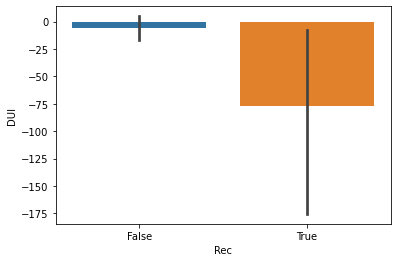

```python
sb.barplot(data=crime_change_df,x="Rec",y="DUI")
```

Make a seaborn `barplot` with "Rec" on the x-axis and "Narcotics" on the y-axis.

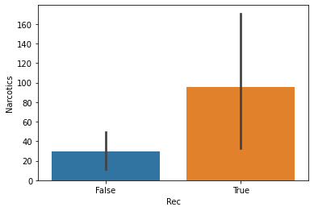

```python
sb.barplot(data=crime_change_df,x="Rec",y="Narcotics")
```

Here's a statistical test for whether the observed differences are statistically significant.

```python
from scipy import stats

rec_dui_changes = crime_change_df.loc[crime_change_df['County'].isin(rec_counties_1),'DUI']
nonrec_dui_changes = crime_change_df.loc[crime_change_df['County'].isin(nonrec_counties_1),'DUI']

stats.ttest_ind(rec_dui_changes,nonrec_dui_changes,equal_var=False)
```

```
Ttest_indResult(statistic=-1.5881060339389734, pvalue=0.12032032904879957)
```

```python
rec_narcotics_changes = crime_change_df.loc[crime_change_df['County'].isin(rec_counties_1),'Narcotics']
nonrec_narcotics_changes = crime_change_df.loc[crime_change_df['County'].isin(nonrec_counties_1),'Narcotics']

stats.ttest_ind(rec_narcotics_changes,nonrec_narcotics_changes,equal_var=False)
```

```
Ttest_indResult(statistic=1.7108143224033967, pvalue=0.09428298061837191)
```

## Discuss

Interpet the observed changes in crime statistics between 2013 and 2019 for legalizing and non-legalizing counties.

## Appendix

Here's the steps I took to collect and clean up some of the data used for this module. **There's nothing you need to run in here to complete any part of this assignment**, I just share it in the interests of transparency and supporting motivated learners.

Libraries only needed for the appendix.

```python
import requests, os, re, time
from bs4 import BeautifulSoup
from urllib.parse import quote, unquote
from datetime import datetime
from io import BytesIO
```

### Sales reports

The Colorado Department of Revenue's [Manrijuana Sales Reports](https://revenue.colorado.gov/data-and-reports/marijuana-data/marijuana-sales-reports) stores Excel files on a Google Drive.

First, get all the links to each month's report by retrieving and parsing the markup from the website.

```python
# Get the raw HTML of the page
raw = requests.get('https://revenue.colorado.gov/data-and-reports/marijuana-data/marijuana-sales-reports')

# Turn into Soup
soup = BeautifulSoup(raw.text)

# Find the elements corresponding to the containers with the yearly data
containers = soup.find_all('dl',{'class':'ckeditor-accordion'})
```

Confirm we got them all.

```python
sorted(excel_files.keys())
```

Define a function to parse the files.

```python
def clean_excel(_df):

    # Drop first 5 rows
    _df = _df.drop(index=range(5)).reset_index(drop=True)

    # Drop empty column
    _df = _df.dropna(how='all',axis=1)

    # Rename columns
    _df.columns = ['Med County','Med Sales','Rec County','Rec Sales']

    # Find row for last medical and recreational sales
    last_med = _df[_df['Med County'].str.contains('Sum of NR Counties').fillna(False)].first_valid_index() - 1
    last_rec = _df[_df['Rec County'].str.contains('Sum of NR Counties').fillna(False)].first_valid_index() - 1

    # Slice to only those values
    med_sales = _df.loc[:last_med,['Med County','Med Sales']]
    rec_sales = _df.loc[:last_rec,['Rec County','Rec Sales']]

    # Rename columns
    med_sales.columns = ['County','Sales']
    rec_sales.columns = ['County','Sales']

    # Add type
    med_sales['Type'] = 'Medical'
    rec_sales['Type'] = 'Recreational'

    # Concatenate
    combined_df = pd.concat([med_sales,rec_sales],ignore_index=True)
    combined_df = combined_df.replace({'Sales':{'NR':np.nan}})

    return combined_df
```

Loop through files, parse out relevant data, and concatenate results together.

```python
cleaned_dict = {}

# Apply the function to each month's spreadsheet
for _month, _df in excel_files.items():
    try:
        cleaned_dict[_month] = clean_excel(_df)
    except:
        print(_month)
        pass

# Combine all the months of data together
combined_df = pd.concat(cleaned_dict.values(),keys=cleaned_dict.keys())

# Cleanup
combined_df = combined_df.reset_index(0).reset_index(drop=True)
combined_df = combined_df.rename(columns={'level_0':'Time'})

combined_df = combined_df.sort_values(['Time','County','Type'])

# Write to disk
combined_df.to_csv('colorado_monthly_cannabis_sales.csv',index=False)

print(combined_df.shape)
combined_df.tail()
```

Old method using files I manually downloaded.

```python
_dir = 'E:/Dropbox/Courses/2020 Fall - INFO 3401/Code and data/cannabis_sales/'
files = [f for f in os.listdir(_dir) if '.xlsx' in f]

data_dict = {}
# filename_prefixes = [i.strftime('%m%y') for i in pd.period_range('2014-01','2020-10',freq='1M')]

_dir = 'E:/Dropbox/Courses/2020 Fall - INFO 3401/Code and data/cannabis_sales/'
files = [f for f in os.listdir(_dir) if '.xlsx' in f]

for month,df in files:
    try:
        period = pd.Period(datetime.strptime(f.split('_')[0],'%m%y'),freq='1M')
        data_dict[period] = pd.read_excel(_dir+f) #,skiprows=5)
    except:
        print(f)
        pass

print(len(data_dict))
```

### Crime

https://coloradocrimestats.state.co.us/public/View/

```python
co_dui_1719 = pd.read_csv('DUI Arrests 2017-2019.csv',skiprows=3).dropna(how='all',axis=1)
co_dui_1316 = pd.read_csv('DUI Arrests 2013-2016.csv',skiprows=3).dropna(how='all',axis=1)

co_dui_df = pd.concat([co_dui_1316,co_dui_1719],ignore_index=True)
co_dui_df['Incident Date'] = pd.to_datetime(co_dui_df['Incident Date'])
co_dui_df = co_dui_df.drop(columns=['Arrest Offense for A and B Arrests'])

co_dui_df = pd.pivot_table(data = co_dui_df,
                           columns = 'Jurisdiction by Geography',
                           index = 'Incident Date',
                           values = 'Number of Arrestees'
                          )

co_dui_df = co_dui_df.fillna(0)

co_dui_df = co_dui_df.groupby(pd.Grouper(freq='1M')).sum().stack().reset_index()
co_dui_df.columns = ['Time','County','Arrests']
co_dui_df['Time'] = co_dui_df['Time'].dt.to_period(freq='1M')

_rename = {c:c.replace(' County','') for c in co_dui_df['County'].unique().tolist() if 'County' in c}
co_dui_df = co_dui_df.replace({'County':_rename})

# co_dui_df.to_csv('co_county_dui.csv')

# co_dui_df.head()
```

```python
co_narcotics_1719 = pd.read_csv('Narcotics Arrests 2017-2019.csv',skiprows=3).dropna(how='all',axis=1)
co_narcotics_1316 = pd.read_csv('Narcotics Arrests 2013-2016.csv',skiprows=3).dropna(how='all',axis=1)

co_narcotics_df = pd.concat([co_narcotics_1316,co_narcotics_1719],ignore_index=True)
co_narcotics_df['Incident Date'] = pd.to_datetime(co_narcotics_df['Incident Date'])
co_narcotics_df = co_narcotics_df.drop(columns=['Arrest Offense for A and B Arrests'])

co_narcotics_df = pd.pivot_table(data = co_narcotics_df,
                           columns = 'Jurisdiction by Geography',
                           index = 'Incident Date',
                           values = 'Number of Arrestees'
                          )

co_narcotics_df = co_narcotics_df.fillna(0)

co_narcotics_df = co_narcotics_df.groupby(pd.Grouper(freq='1M')).sum().stack().reset_index()
co_narcotics_df.columns = ['Time','County','Arrests']
co_narcotics_df['Time'] = co_narcotics_df['Time'].dt.to_period(freq='1M')

_rename = {c:c.replace(' County','') for c in co_narcotics_df['County'].unique().tolist() if 'County' in c}
co_narcotics_df = co_narcotics_df.replace({'County':_rename})

# co_narcotics_df.to_csv('co_county_narcotics.csv')

# co_narcotics_df.head()
```

```python
co_county_crime_df = pd.concat([co_dui_df,co_narcotics_df],
                               keys=['DUI','Narcotics'],
                               names=['Type']
                              ).reset_index(0)
co_county_crime_df = co_county_crime_df[['Time','County','Type','Arrests']]

co_county_crime_df = co_county_crime_df.sort_values(['Time','County','Type']).reset_index(drop=True)

co_county_crime_df.to_csv('co_county_crime.csv',index=False)

co_county_crime_df.head()
```

```python
co_county_crime_df = pd.merge(left = co_dui_df,
                              right = co_narcotics_df,
                              how = 'outer',
                              left_on = ['Time','County'],
                              right_on = ['Time','County']
                             )

co_county_crime_df.to_csv('co_county_crime.csv',index=False)

co_county_crime_df.head()
```